# Norfolk Gentrification & Displacement Dashboard

UDP Typology Map, Norfolk VA (2014–2024)

[interactive chart not shown]

This approach is based in the [Urban Displacement Project’s](https://www.urbandisplacement.org/) gentrification and displacement methodology.

UDP Typology Criteria (Adapted for Norfolk)

[output not shown]

Census tract 51710003800 contains the West Ghent neighborhood which has history of Black resident displacement and subsequent reinvestment[^1] dating back to the Urban Renewal Era[^2] and is the only tract within the Advanced Gentrification category.

There are five Census tracts in the Early/Ongoing Gentrification category:

- Tract 51710007002 contains the Poplar Halls, Elizabeth Park, and Woodbine neighborhoods.
- Tract 51710003200 contains the southernmost half of the Fairmount Park neighborhood.
- Tract 51710006000 contains the Norview and Greenwood neighborhoods.
- Tract 51710000700 contains the Northside neighborhood.
- Tract 51710000100 contains the Cottage Park neighborhood.

The Census data and the map on this tab provide a sense of where each of the tracts in Norfolk began and ended on the gentrification spectrum between 2014 and 2024. Take a look at the **Home Sales & Rents** tab to see how real estate sales, rising rents, and land use changes offer further insights.

*Defining Gentrification*

Gentrification [is a process](https://www.planetizen.com/definition/gentrification) where [investment and more affluent households](https://voorheescenter.uic.edu/what-we-do/areas-of-research/gentrification-index/gentrification-faq/) move into low-income neighborhoods often resulting in the displacement of existing residents. Explanations for why and where gentrification occurs in urban areas usually focus on the supply-side or on the demand-side of housing markets. The [rent-gap explanation](https://www.planning.org/blog/9177620/neil-smith-gentrification-and-the-flow-of-money/) emphasizes housing supply factors like profit-seeking behavior and speculation on the part of [individual and institutional investors](https://shelterforce.org/2022/08/08/what-is-the-financialization-of-housing/). The rent-gap framework is based on a simple and intuitive mechanism—central city areas where the disparity between current value and the expected value after renovation or redevelopment is greatest are the most attractive to investors. The underlying assumption here is that the provision of housing is first and foremost a profit-seeking endeavor, so central city neighborhoods where property can be acquired at low cost and but that also has a high resale potential are ideal candidates for gentrification.

Other explanations of gentrification focus on demand-side factors like changes preferences on the part of individuals or households with the higher purchasing power. The general argument here centers on changing demographics and evolving preferences with greater value placed on the centrality (e.g., living near downtown areas), diversity, and amenities that characterize many city neighborhoods that have experienced disinvestment or decline. While primary concern voiced by critics of gentrification has been the loss of affordable housing and displacement of current residents, there are also arguments in favor of gentrification or at the very least, [opposing viewpoints](https://cityobservatory.org/how-gentrification-benefits-long-time-residents-of-low-income-neighborhoods/) that highlight positive outcome such as infrastructure upgrades, reduced crime, and deconcentration of poverty.

*Residential Property Values and Gentrification*

Economic theory suggests that land in central cities is valued more highly and therefore, used more intensively than land on the urban fringe. Households tradeoff consumption of land and housing for greater accessibility, which means prices tend to fall as you move away from the city center. However, given the shift from the more conventional single center of employment and economic activity (e.g., a downtown or central business district) to multiple nodes of employment and commercial activity in many of the metropolitan areas around the United States, that way of thinking about land in cities has changed. As employment opportunities have become less centralized, transportation infrastructure investments have increased travel speeds, and remote work has become more common, property located on the urban fringe increased in value. Suburbanization and [white flight](https://en.wikipedia.org/wiki/White_flight) during the decades following World War II contributed to the patterns of disinvestment in central city neighborhoods that set the stage for subsequent redevelopment and gentrification.

Beyond the interaction of land use and transportation, social and demographic factors are also important in determining where different groups locate in cities and relative property values. A variety of neighborhood characteristics are capitalized into residential property values and this provides an essential link to the gentrification process. Gradual improvements in housing stock, the arrival of a more affluent or educated resident population, and positive [externalities](https://en.wikipedia.org/wiki/Externality) from proximity to wealthier areas bolster residential property values in gentrifying neighborhoods. The population growth itself increases demand for housing, but demographic changes—for example an influx of young professionals—can impact the types of residential development that are favored as well as builders and developers respond the perceived preferences of a new and growing customer base.

*Mapping the Gentrification Process*

The map to left is based on [an approach established](https://www.urbandisplacement.org/topic/global-urban-displacement/) by researchers based at the UC Berkeley and the University of Toronto. We have adapted the gentrification and displacement mapping methodology from the *Urban Displacement Project* (UDP) for Norfolk and the shaded polygons represent the 81 Census tracts within the city. The table to the bottom right shows the number of Norfolk Census tracts that fall within each of the categories using 2014 as the start year and 2024 and the end year for this analysis. The data used are taken from the U.S. Census Bureau’s American Community Survey and because tract boundaries change over time, an areal weighting approach was used to reconcile the 2010 and 2020 boundaries when necessary.

In adapting the UDP typology to Norfolk, we consider median household income for each Census tract and assign each to an income tier (i.e., low, moderate, or high) relative to the Virginia Beach-Norfolk-Newport News MSA median in 2014 which was $56,406. Next, we incorporate educational attainment in the form of the percentage of tract residents with a Bachelor’s degree or higher. Housing costs are considered with measures of median rent and median home value and a tract is only considered gentrifying if both rent and home values are outpacing the metropolitan region. Displacement is captured by calculating the absolute decline in low-income households with a threshold of greater than 5% to allow for a situation where a tract loses low-income households while growing overall. We also track change in race and ethnicity of the resident population and change in renter population, but these data do not factor into how Census tracts are categorized—these values are presented in the pop-up window if you click one of the Census tracts in the map, however.

© Bev Wilson 2026 | Department of Urban + Environmental Planning | University of Virginia

The map to the right shows a composite gentrification pressure measure that is presented as a z-score. A [z-score captures the degree of dispersion or spread](https://en.wikipedia.org/wiki/Standard_score) within a set of data values and it represented number of standard deviations a particular Census tract is above or below the mean level of gentrification pressure. This measure complements the UDP typology category assigned to each of Norfolk’s Census tracts in the **UDP Typology Map** tab by quantifying the relative intensity of the gentrification pressure that each experienced between 2014 and 2024. The composite gentrification pressure measure is based on the following factors:

- *Excess income growth*: The percent change in household income within the Census tract minus the percent change in household income for the metropolitan area
- *Education*: Change in the percentage of Census tract residents with a Bachelor’s degree of higher
- *Housing cost*: Average of Excess value growth and Excess rent growth
  - *Excess value growth*: The percent change in median home value in the Census tract minus the percent change in median home value for the metropolitan area
  - *Excess rent growth*: The percent change in median rent in the Census tract minus the percent change in median rent for the metropolitan area

For each of the gentrification factors shown above, data were drawn from the 2014 and 2024 American Community Survey 5-Year Estimates.

When interpreting the gentrification pressure scores a value of 0 means the tract sits right at the citywide average across all three of the factors combined. A positive value means more gentrification pressure than the typical Norfolk tract (i.e., faster-than-MSA income/rent/value growth, rising education) while a negative value means less gentrification pressure than the typical Norfolk tract. The gentrification pressure score only exists for the 77 tracts that have a full set of non-missing values on all three inputs and a UDP typology classification—any unclassified tracts are excluded and shown as grey on the map.

The *darkest Census tracts* in the map experienced the *greatest gentrification pressure* from 2014 to 2024 based on the factors outlined above. The Census tracts containing the Chesterfield, Oceanair, Park Place, and Shore Drive neighborhoods scored the highest on the composite gentrification pressure measure, along with the West Ghent neighborhood which is already in the advanced stages of gentrification.

The bar chart to the left below shows the average sales price for residential properties by month and Census tract with the [tract containing the Ingleside neighborhood](https://data.census.gov/profile/Census_Tract_64;_Norfolk_city;_Virginia?g=1400000US51710006400) to the east of Norfolk State University as the default. These sales data were taken directly from the city’s property assessment and sales records [available here](https://data.norfolk.gov/browse?federation_filter=1370&sortBy=relevance&pageSize=20&q=Property+assessment+and+sales).

Homes located in the five Early/Ongoing Gentrification tracts have larger lots than the rest of the city, but the size of those lots has been falling over time. This could be a consequence of home on larger, older lots being subdivided or redeveloped into smaller, higher-density housing (e.g., a single-family home being redeveloped as several townhomes on the same land).

The bar chart to the right below shows the average asking rent for residential properties by month and Census tract with the [tract containing the Ingleside neighborhood](https://data.census.gov/profile/Census_Tract_64;_Norfolk_city;_Virginia?g=1400000US51710006400) to the east of Norfolk State University as the default. These rent data[^3] were accessed through the University of Virginia’s license with Dewey Data and represent “residential real estate rental listing data, including pricing, property information, location, and more” on a weekly basis for over 41,000 zip codes. Rent data collected for Norfolk prior to 2023 appear to be less reliable and have been excluded.

Gentrification Pressure (Click a Census Tract to Update the Charts Below)

[interactive chart not shown]

Mean Residential Sale Price by Month (since 2023)

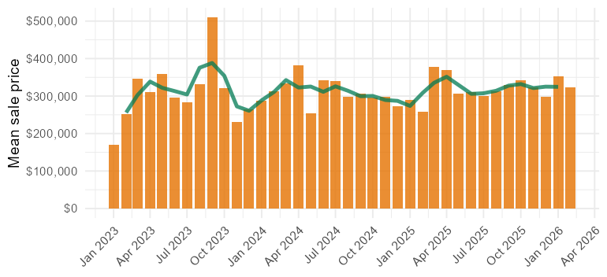

Defaults to the [tract](https://data.census.gov/profile/Census_Tract_64;_Norfolk_city;_Virginia?g=1400000US51710006400) containing the Ingleside neighborhood.

Mean Asking Rent by Month (since 2023)

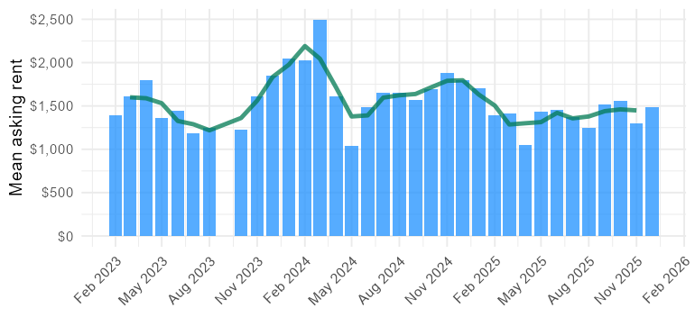

Defaults to the [tract](https://data.census.gov/profile/Census_Tract_64;_Norfolk_city;_Virginia?g=1400000US51710006400) containing the Ingleside neighborhood.

© Bev Wilson 2026 | Department of Urban + Environmental Planning | University of Virginia

Gentrification Pressure & Coastal Flood Risk

[interactive chart not shown]

*Gentrification Pressure & Coastal Flood Risk*

Norfolk is exposed to [fluvial](https://www.zurich.com/-/media-assets/project/zurich/dotcom/industry-knowledge/flood-and-water-damage/images/infographic-fluvial-or-river-flood.jpg) flooding, [pluvial](https://www.zurich.com/-/media-assets/project/zurich/dotcom/industry-knowledge/flood-and-water-damage/images/infographic-pluvial-floods-flash-floods-and-surface-water.jpg) flooding, more frequent and stronger [coastal storms](https://www.zurich.com/-/media-assets/project/zurich/dotcom/industry-knowledge/flood-and-water-damage/images/infographic-coastal-floods-and-storm-surge.jpg), rising [sea levels](https://sealevel.nasa.gov/internal_resources/549/Causes%20of%20Global%20Sea%20Level%20Rise.jpeg), and the [ongoing sinking or subsidence](https://www.whro.org/environment/2026-02-20/hampton-roads-is-sinking-by-2-millimeters-each-year-new-data-shows) of the land itself.

The map to the left shows the composite gentrification pressure measure from the **Home Sales & Rents** tab alongside four layers that capture some aspect of coastal flood risk. The Federal Emergency Management Agency or FEMA defines the 100-year floodplain as those areas with a 1% chance of flooding in any given year. The 100-year floodplain is the basis for much of the development regulations, including mandatory purchase of flood insurance in order to qualify for a government-backed mortgage. By contrast the 500-year floodplain as those areas with a 0.2% chance of flooding in any given year and is generally considered moderate to low flood risk. Because climate change is shifting the distribution of flood risk, [some have suggested using the 500-year floodplain](https://www.floods.org/news-views/policy-matters/rethinking-our-nations-flood-standards/) as the basis for regulating floodplain development instead.

Sea level rise occurs primarily through [melting ice sheets](https://www.whoi.edu/ocean-learning-hub/ocean-topics/climate-weather/sea-level-rise/) and thermal expansion (i.e., as the planet warms, the water in the oceans physically expands). The sea level rise layer in the map to the left was created by the National Oceanic and Atmospheric Association or NOAA[^4] and represents the intermediate scenario of 1.5 feet in the year 2050 for Norfolk and coastal Virginia, which is [believed to be most likely](https://oceanservice.noaa.gov/hazards/sealevelrise/sealevelrise-tech-report-graphics.html) at this point in time. Although the sea level rise layer closely tracks the 100-year floodplain, they are essentially attempting to capture existing/past flood risk versus future flood risk.

There is also a [layer that shows the number of National Flood Insurance Program or NFIP building flood damage claims ever paid by Census tract](https://data.norfolk.gov/Government/FEMA-NFIP-Total-Dollar-Amounts-of-Claims-grouped-b/6b4u-jd34/about_data) taken from the city’s open data portal. These values represent damages to the structure itself and do not include claims paid for flood damage to the contents of affected structures. In Norfolk, total NFIP building damage claims paid range from $285 to nearly $14 million and eight of the 81 tracts have missing data.

Housing markets typically take disamenities like noise, air pollution, crime, or proximity to locally unwanted land uses (LULUs) like landfills into account and these factors influence home sales and rents. There are also studies that show homes located within a FEMA designated flood zone sell for less[^5][^6]than comparable properties outside those areas, but the size of the discount varies and often it is not detectable until *after* a major flood event occurs. There is some evidence that rents respond more sharply to flooding than home sales[^7], perhaps because renters tend to be more mobile than homeowners with a mortgage.

While flooding from rivers, extreme rainfall, and coastal storms are familiar to residents of cities like Norfolk, the effects of sea level rise are more abstract and can seem like a less immediate threat. However, several studies suggest that housing markets—like insurers—are beginning to explicitly factor future flood risk from sea level rise into prices with reduced demand for exposed properties as consequence[^8] and that the desire to avoid the most flood-exposed areas of coastal cities may now be directing gentrification processes on the ground. The idea is that the [rent-gap explanation](https://www.planning.org/blog/9177620/neil-smith-gentrification-and-the-flow-of-money/) of gentrification has to now be expanded to accommodate risk avoidance strategies like purchasing property in locations that have higher elevations or that are protected by existing (or planned) flood mitigation infrastructure like levees and floodwalls[^9].

This preliminary analysis shows that both flood risk (i.e., the 100-year floodplain) and sea level rise exposure in 2050 are largely concentrated in Norfolk’s more affluent Census tracts (i.e., the Stable Moderate/Mixed Income and Stable/Advanced Exclusive categories) rather than those experiencing or at risk of gentrification and displacement (e.g., Ongoing Displacement category).

© Bev Wilson 2026 | Department of Urban + Environmental Planning | University of Virginia

## Footnotes

[^1]: Solomon, M. (2025). Toxic capture. In *The Elsewhere Is Black: Ecological Violence and Improvised Life* (pp. 30-58). Durham, NC: Duke University Press.
[^2]: Finn, J.C. (2024). Urban renewal in Norfolk, VA: Race, Segregation, and the (re)production of landscapes of inequality. *Nonsite.Org*, 47. Available at https://nonsite.org/urban-renewal-in-norfolk-va-race-segregation-and-the-reproduction-of-racialized-economic-inequality
[^3]: RentHub. (2022). Rental Data [Dataset]. Dewey Data. https://doi.org/10.82551/5MMV-7M10
[^4]: Office for Coastal Management. (2026). *NOAA Office for Coastal Management Sea Level Rise Data: 1-10 ft Sea Level Rise Inundation Extent*. Available at https://www.fisheries.noaa.gov/inport/item/48106
[^5]: Akinlotan, P., Davlasheridze, M., Atoba, K., & Highfield, W. (2026). Flood Risk Discounts: Evidence from Housing Market in Harris County, Texas. *Economics of Disasters and Climate Change*, 10(1), 13.
[^6]: Catma, S. (2021). The price of coastal erosion and flood risk: A hedonic pricing approach. *Oceans*, 2(1), 149-161.
[^7]: Lee, S., & Zheng, S. (2026). Annoyed, but Not Alarmed: Sea Level Rise, Chronic Inundation, and Coastal Housing Markets. *Journal of Real Estate Finance and Economics*, 73, 548–574.
[^8]: Keys, B. J., & Mulder, P. (2020). *Neglected no more: Housing markets, mortgage lending, and sea level rise (No. w27930)*. Cambridge, MA: National Bureau of Economic Research. Available at https://www.nber.org/papers/w27930
[^9]: Keenan, J. M., Hill, T., & Gumber, A. (2018). Climate gentrification: from theory to empiricism in Miami-Dade County, Florida. *Environmental Research Letters*, 13(5), 054001.